# Visualization_P.Rmd

N Naveen

2023-11-07

```r
library("MASS")
```

```r
newsurvey = na.omit(survey)
View(newsurvey)
```

```r
library(ggplot2)
```

##1. Plot a bar graph for the number of male and female participants in the survey. Provide the title as “Male and Female participants”, y-axis label as “frequency” and specify the colours for the bars.

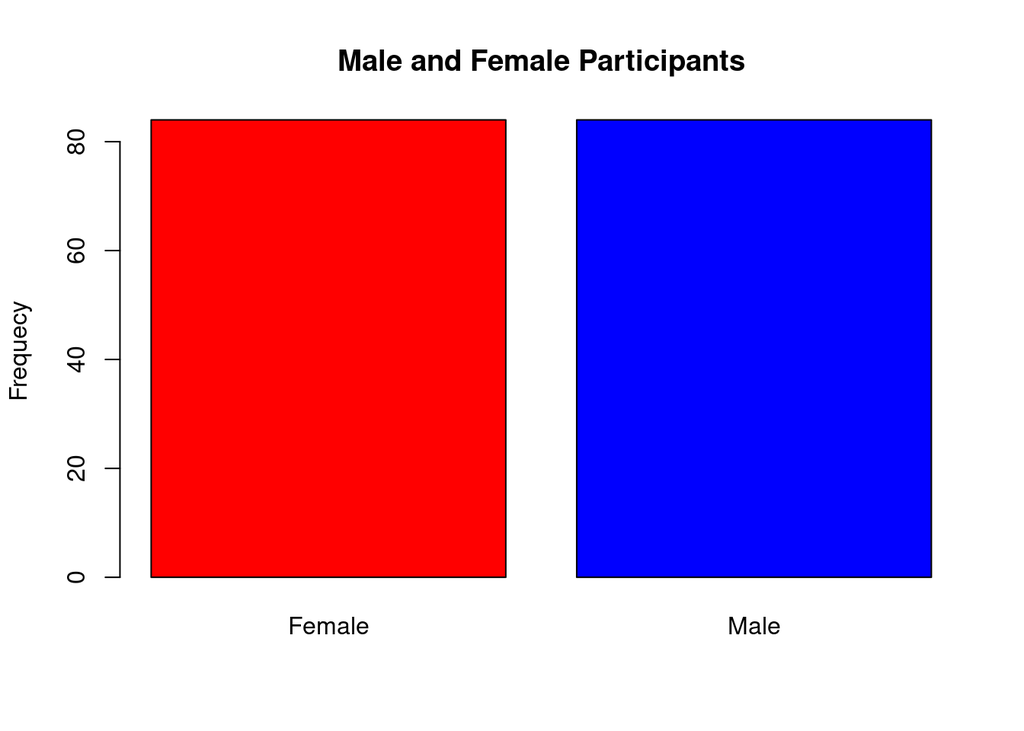

```r
freq = table(newsurvey$Sex)
barplot(freq, main = "Male and Female Participants", ylab = "Frequecy", col = c("red","blue"))
```

## 2.Plot a bar graph for the number of left handers and right handers in the survey. Provide the title as “Left Handers and Right Handers”, y-axis label as “count” and specify the colours for the bars.

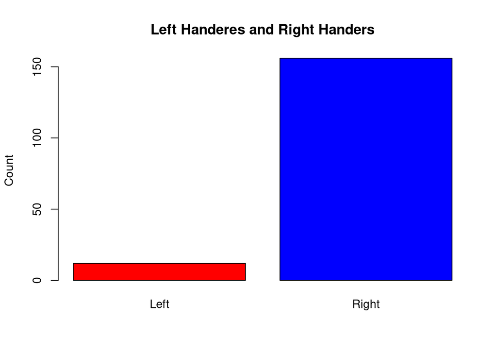

```r
count = table(newsurvey$W.Hnd)
barplot(count,main = "Left Handeres and Right Handers", ylab = "Count",col = c("red","blue"))
```

## 3.Plot the distribution between male left handers and female left handers using bar chart. Provide the title as “Female Left Handers and Male Left Handers , y-axis label as “count” and specify the colours for the bars.

```r
library(dplyr)
```

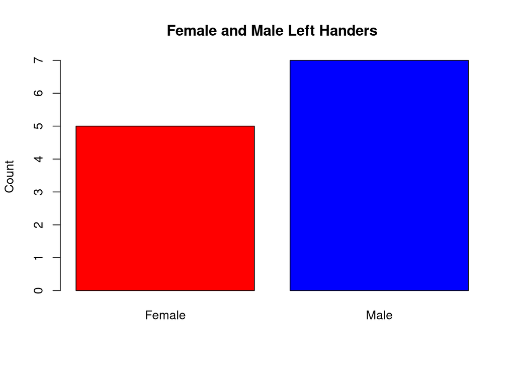

```r
d1 = newsurvey %>% filter(W.Hnd == "Left")
count = table(d1$Sex)
barplot(count,main = "Female and Male Left Handers",ylab = "Count" ,col = c("red","blue"))
```

## 4.Draw the histogram of age distribution with the title as „Age distribution‟ and xlabel as „Age range‟ and ylabel as „frequency‟.

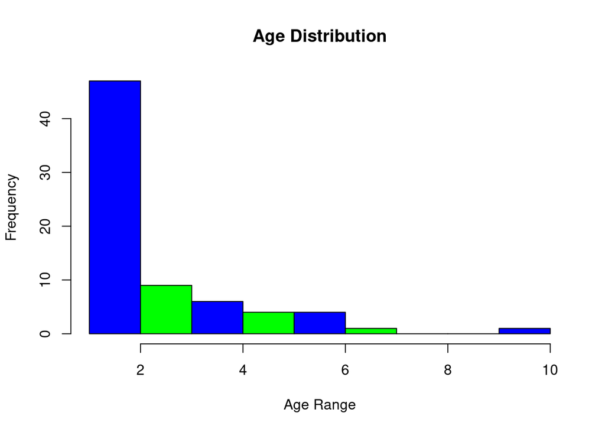

```r
freq = table(newsurvey$Age)
hist(freq, main = "Age Distribution", xlab = "Age Range", ylab = "Frequency", col = c("blue", "green"))
```

## 5.Reveal the relationship between the age and writing hand span using scatter plot.

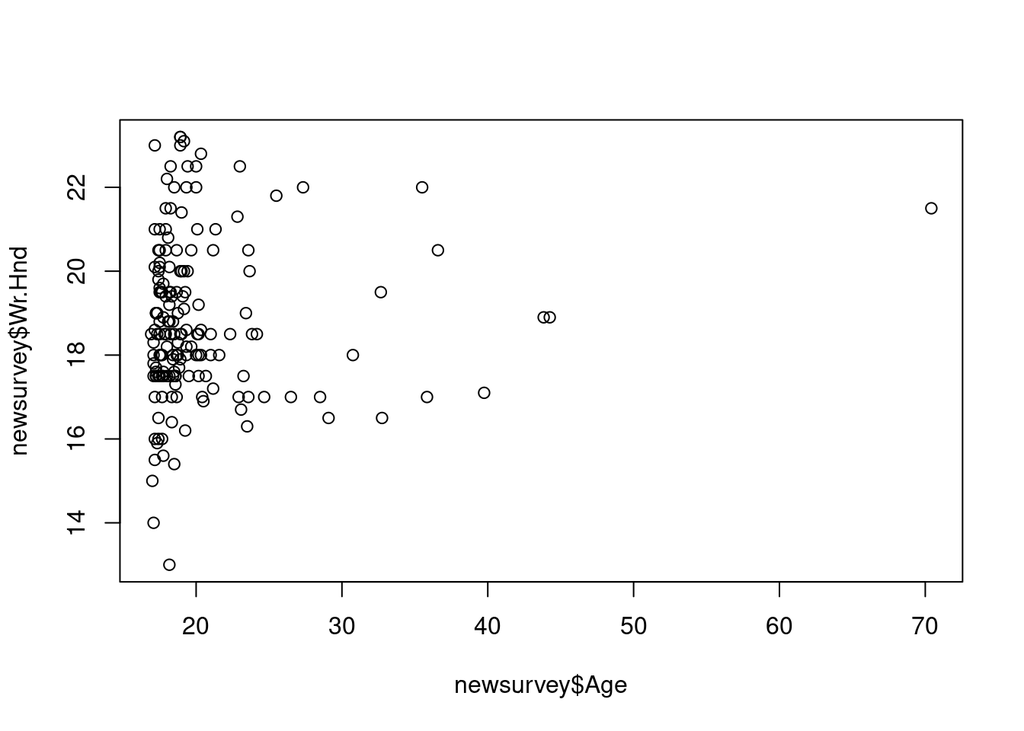

```r
plot(newsurvey$Age, newsurvey$Wr.Hnd)
```

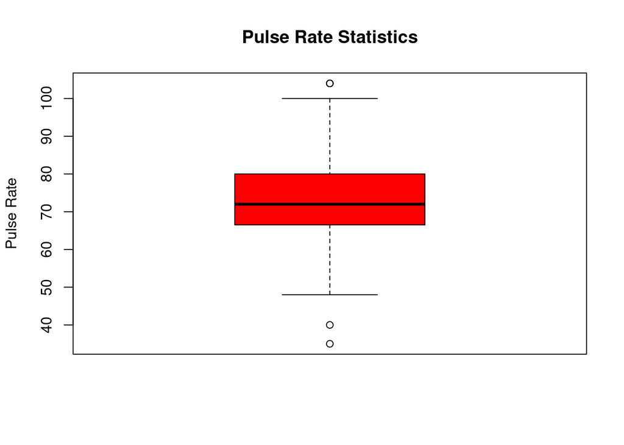

```r
boxplot(newsurvey$Pulse, main = "Pulse Rate Statistics",ylab = "Pulse Rate",col = "red")
```

```r
summary(newsurvey$Pulse)
```

```
##    Min. 1st Qu.  Median    Mean 3rd Qu.    Max.
##   35.00   66.75   72.00   74.02   80.00  104.00
```

## 7.Draw the distribution of smoking habits of male left handers using pie chart.

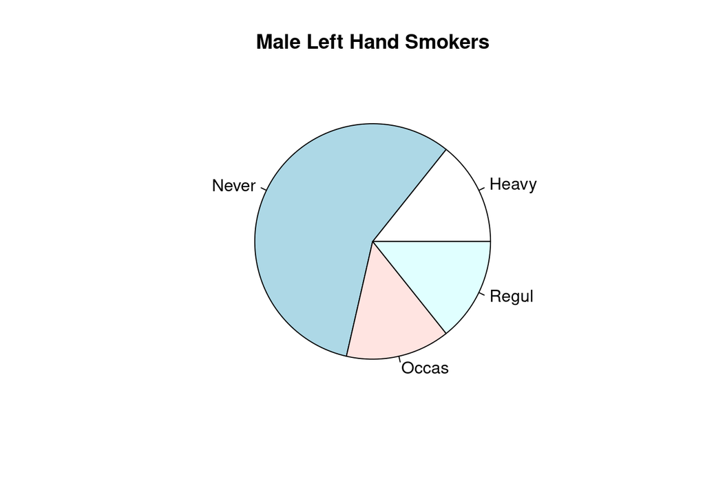

```r
M_L = d1 %>% filter(Sex == "Male")
count = table(M_L$Smoke)
pie(count, main = "Male Left Hand Smokers")
```

```r
file1 <- read.csv("/home/ex5/Desktop/22mia1049/Sample Datasets-20230926/iris.csv")
data1 = na.omit(file1)
data1
```

```
##      Id Sepal.Length Sepal.Width Petal.Length Petal.Width         species
## 1     1          5.1         3.5          1.4         0.2     Iris-setosa
## 2     2          4.9         3.0          1.4         0.2     Iris-setosa
## 3     3          4.7         3.2          1.3         0.2     Iris-setosa
## 4     4          4.6         3.1          1.5         0.2     Iris-setosa
## 5     5          5.0         3.6          1.4         0.2     Iris-setosa
## 6     6          5.4         3.9          1.7         0.4     Iris-setosa
## 7     7          4.6         3.4          1.4         0.3     Iris-setosa
## 8     8          5.0         3.4          1.5         0.2     Iris-setosa
## 9     9          4.4         2.9          1.4         0.2     Iris-setosa
## 10   10          4.9         3.1          1.5         0.1     Iris-setosa
## 11   11          5.4         3.7          1.5         0.2     Iris-setosa
## 12   12          4.8         3.4          1.6         0.2     Iris-setosa
## 13   13          4.8         3.0          1.4         0.1     Iris-setosa
## 14   14          4.3         3.0          1.1         0.1     Iris-setosa
```

[output cut: 136 more lines]

## Correalation Analysis

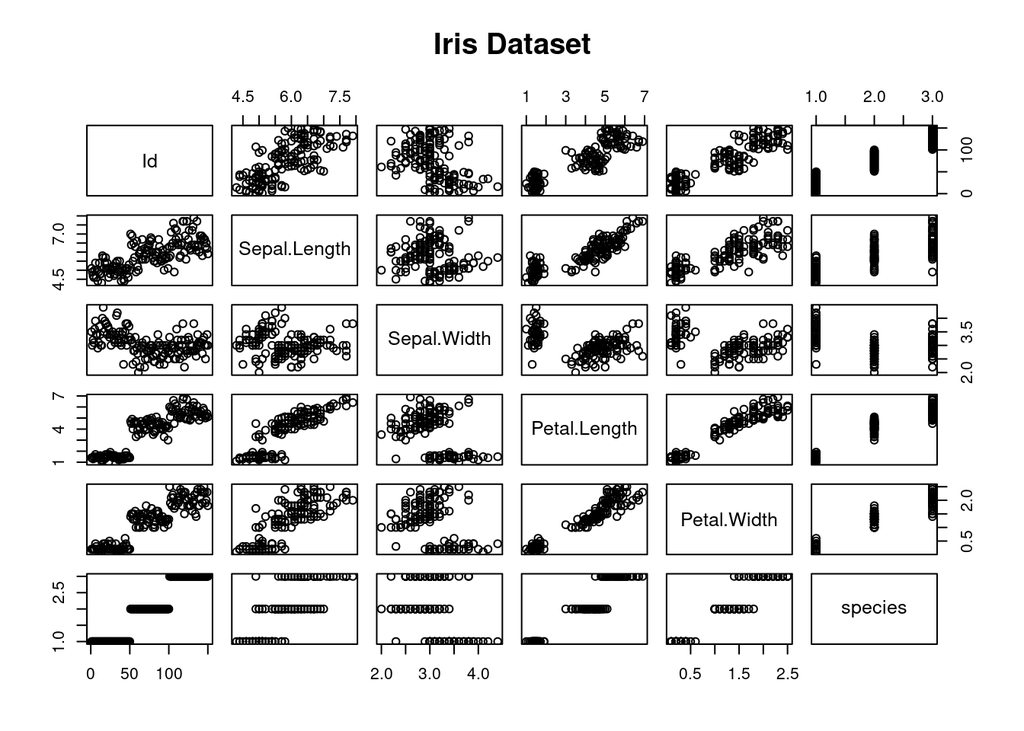

```r
plot(file1,main = "Iris Dataset")
```

## Outliers

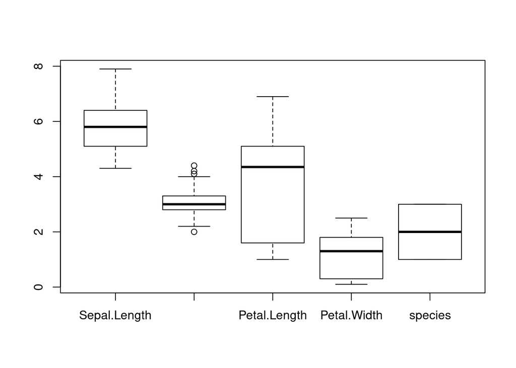

```r
boxplot(data1[,2:6], "Outliers")
```

## Plot the frequency table

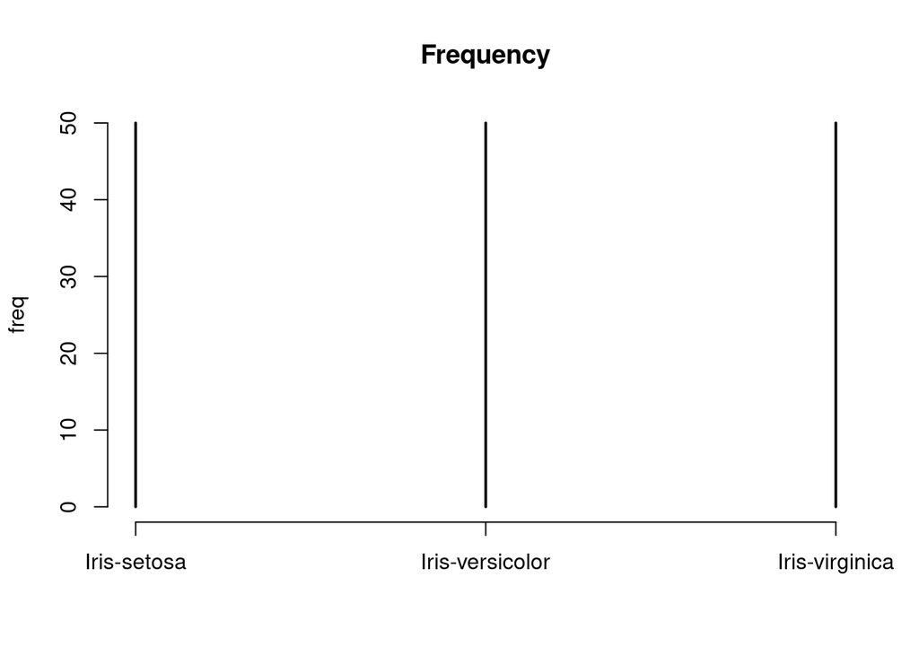

```r
freq = table(data1$species)
plot(freq,main = "Frequency")
```